# Analysis

```r
# Load data
d3cp <- read.csv('C:\\Users\\millerry\\Downloads\\analysisTasks3.csv')
d3n <- read.csv('C:\\Users\\millerry\\Downloads\\analysisTasksNoEngage3.csv')

#d3cp <- read.csv('C:\\Users\\Ryan M\\Downloads\\analysisTasks3.csv')
#d3n <- read.csv('C:\\Users\\Ryan M\\Downloads\\analysisTasksNoEngage3.csv')

# Manually remove repeats
d3n <- d3n[-which(d3n$DaqName %in% c("20130612092744.csv", "20140104105417.csv")),]
d3cp <- d3cp[-which(d3cp$DaqName %in% c("20130612092744.csv", "20140104105417.csv")),]
```

## Visuals

Standard deviation of lane deviation by dosage group and secondary task engagement:

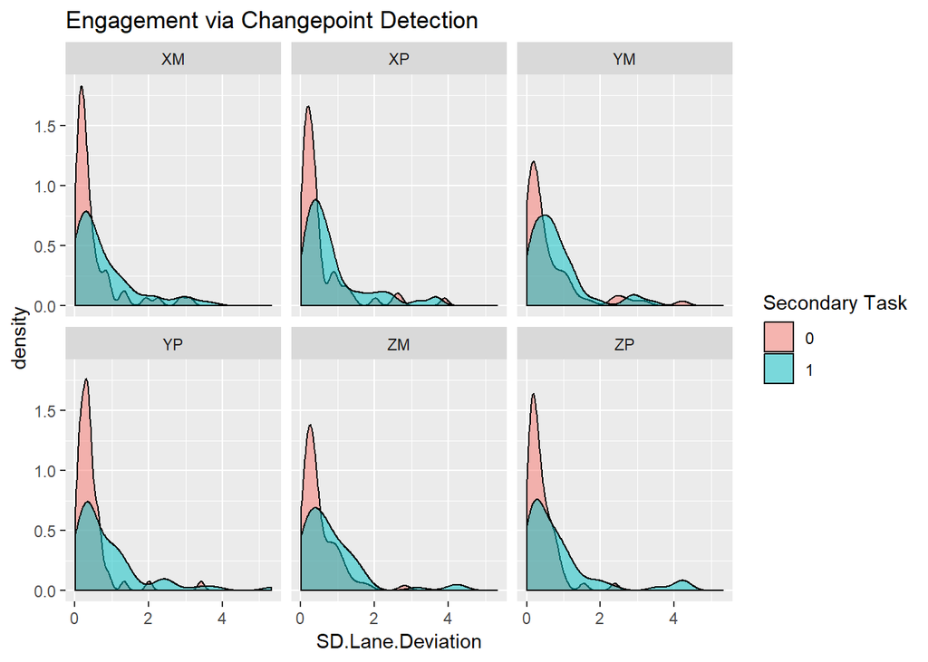

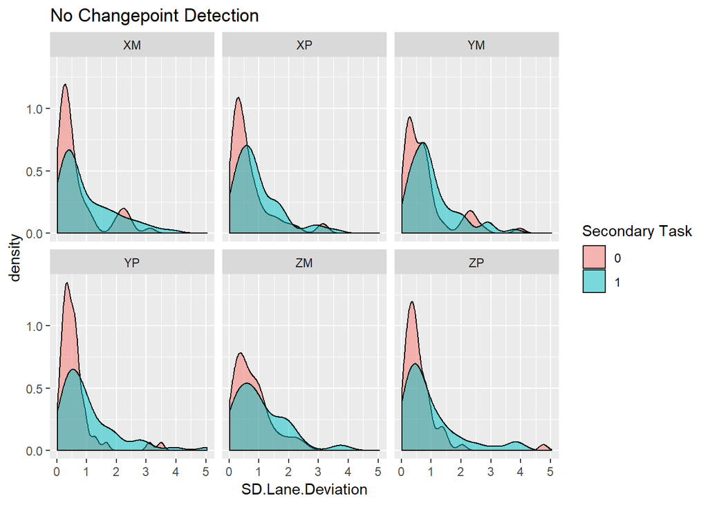

Boxplot version:

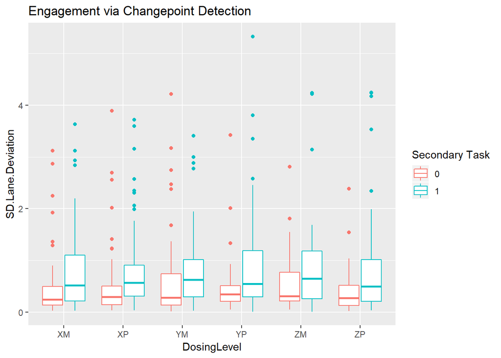

Paired version:

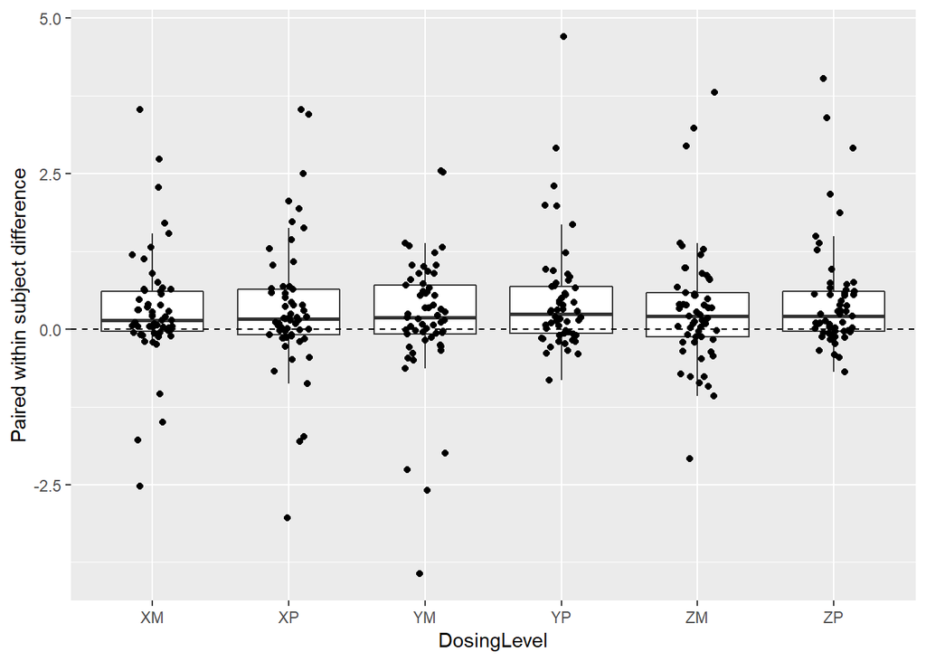

## Tables

Secondary task segments available for analysis for each of the 19 subjects:

|  | XM | XP | YM | YP | ZM | ZP | Sum |
| --- | --- | --- | --- | --- | --- | --- | --- |
| Subject ID 3 | 3 | 3 | 3 | 3 | 3 | 3 | 18 |
| Subject ID 7 | 3 | 3 | 3 | 3 | 3 | 3 | 18 |
| Subject ID 10 | 3 | 3 | 3 | 3 | 3 | 3 | 18 |
| Subject ID 15 | 3 | 3 | 3 | 3 | 3 | 3 | 18 |
| Subject ID 17 | 3 | 3 | 3 | 3 | 3 | 3 | 18 |
| Subject ID 18 | 3 | 3 | 3 | 3 | 3 | 3 | 18 |
| Subject ID 21 | 3 | 3 | 3 | 3 | 3 | 3 | 18 |
| Subject ID 25 | 3 | 3 | 3 | 3 | 3 | 3 | 18 |
| Subject ID 26 | 3 | 3 | 3 | 3 | 3 | 3 | 18 |
| Subject ID 29 | 3 | 3 | 3 | 3 | 3 | 3 | 18 |
| Subject ID 31 | 3 | 3 | 3 | 3 | 3 | 3 | 18 |
| Subject ID 32 | 3 | 3 | 3 | 3 | 3 | 3 | 18 |
| Subject ID 34 | 3 | 3 | 3 | 3 | 3 | 3 | 18 |
| Subject ID 35 | 3 | 3 | 3 | 3 | 3 | 3 | 18 |
| Subject ID 104 | 3 | 3 | 3 | 3 | 3 | 3 | 18 |
| Subject ID 113 | 3 | 3 | 3 | 3 | 3 | 3 | 18 |
| Subject ID 120 | 3 | 3 | 3 | 3 | 3 | 3 | 18 |
| Subject ID 123 | 3 | 3 | 3 | 2 | 3 | 3 | 17 |
| Subject ID 129 | 2 | 3 | 3 | 3 | 3 | 3 | 17 |
| Sum | 56 | 57 | 57 | 56 | 57 | 57 | 340 |

Marginally, there is a statistically significant effect of secondary task engagement (for most Dose/Event combos) on standard deviation of lane deviation (p-values are from paired t-tests within subject/event):

| DosingLevel | EventID | mean_SDL | sd_SDL | n | p_value | signif |
| --- | --- | --- | --- | --- | --- | --- |
| XM | 1 | -0.1079823 | 0.6653311 | 19 | 0.47929 |  |
| XM | 2 | 0.3852318 | 1.0004674 | 18 | 0.10234 |  |
| XM | 3 | 0.6290988 | 0.9803059 | 19 | 0.00515 | ** |
| XP | 1 | 0.3818299 | 0.8399112 | 19 | 0.04753 | * |
| XP | 2 | 0.1759859 | 1.4630276 | 19 | 0.60005 |  |
| XP | 3 | 0.4446652 | 0.8482441 | 19 | 0.02231 | * |
| YM | 1 | 0.2406506 | 0.9370421 | 19 | 0.26295 |  |
| YM | 2 | -0.1298222 | 1.3342822 | 19 | 0.67149 |  |
| YM | 3 | 0.4220633 | 0.7426300 | 19 | 0.01324 | * |
| YP | 1 | 0.4575804 | 0.8007496 | 19 | 0.01274 | * |
| YP | 2 | 0.5653850 | 1.1621832 | 18 | 0.03902 | * |
| YP | 3 | 0.3885585 | 0.7604960 | 19 | 0.02594 | * |
| ZM | 1 | 0.2998543 | 1.0046808 | 19 | 0.19328 |  |
| ZM | 2 | 0.0252731 | 1.0177404 | 19 | 0.91380 |  |
| ZM | 3 | 0.6257512 | 0.8121137 | 19 | 0.00078 | *** |
| ZP | 1 | 0.4451658 | 1.0555926 | 19 | 0.06603 | . |
| ZP | 2 | 0.5386620 | 1.0042601 | 19 | 0.01939 | * |
| ZP | 3 | 0.4225396 | 0.6069259 | 19 | 0.00241 | ** |

## Models

### Model 1 - Base Model

$$y_{ij} = \beta_0 + \gamma_i + \beta_1 SecTask_{ij} + \beta_2 DoseXM_{ij} + \beta_3 DoseYM_{ij} + \ldots + \epsilon_{ij}$$

- $y_{ij}$ = Standard Deviation of lane deviation for subject $i$ at dosing level $j$
- $\gamma_i$ = subject specific random intercept
- $SecTask_{ij}$ = dummy variable indicating observation measures performance during secondary task (1 = sec task, 0 = control segment)
- $DoseAA_{ij}$ = dummy variable for dose = “AA” (1 = specified dose, 0 = reference group)
  - In our models we will re-define the reference group such that all dose effects are positive

```r
d3cp$Dose_Grp <- relevel(d3cp$DosingLevel, ref = "ZP")
fit <- lmer(data = d3cp, SD.Lane.Deviation ~ Dose_Grp +  Experiment  + (1 | ID))

fit_sum <- summary(fit)
kable(round(fit_sum$coefficients, 4))
```

|  | Estimate | Std. Error | df | t value | Pr(>\|t\|) |
| --- | --- | --- | --- | --- | --- |
| (Intercept) | 0.4598 | 0.0853 | 171.3511 | 5.3935 | 0.0000 |
| Dose_GrpXM | 0.0154 | 0.1012 | 655.1849 | 0.1522 | 0.8790 |
| Dose_GrpXP | 0.0756 | 0.1007 | 654.9280 | 0.7502 | 0.4534 |
| Dose_GrpYM | 0.0873 | 0.1007 | 654.9280 | 0.8665 | 0.3865 |
| Dose_GrpYP | 0.0517 | 0.1012 | 655.1849 | 0.5109 | 0.6096 |
| Dose_GrpZM | 0.0454 | 0.1007 | 654.9280 | 0.4507 | 0.6524 |
| Experiment | 0.3443 | 0.0583 | 654.9280 | 5.9029 | 0.0000 |

```r
kable(round(anova(fit), 4))
```

|  | Sum Sq | Mean Sq | NumDF | DenDF | F value | Pr(>F) |
| --- | --- | --- | --- | --- | --- | --- |
| Dose_Grp | 0.6434 | 0.1287 | 5 | 655.0996 | 0.2226 | 0.9528 |
| Experiment | 20.1476 | 20.1476 | 1 | 654.9280 | 34.8437 | 0.0000 |

This model suggests a significant effect of secondary task engagement on standard deviation of lane deviation, but no impact of experimental condition

- A few problems with it:
  - Doesn’t adjust for differences in speed
  - Skewed distribution of `SD.Lane.Deviation`
  - Treats all 3 secondary tasks as the same
  - It also isn’t looking for effect modification by `Dose_Grp`

### Model 2 - Log-transformed outcome, control for eventNum and Avg.Speed

```r
fit <- lmer(data = d3cp, log2(SD.Lane.Deviation) ~ relevel(DosingLevel, ref = "XM") +
              factor(eventNum)  + Avg.Speed + Experiment + (1 | ID))

kable(round(summary(fit)$coefficients, 4))
```

|  | Estimate | Std. Error | df | t value | Pr(>\|t\|) |
| --- | --- | --- | --- | --- | --- |
| (Intercept) | -3.9636 | 0.5686 | 370.8770 | -6.9712 | 0.0000 |
| relevel(DosingLevel, ref = “XM”)XP | 0.1522 | 0.1954 | 652.9692 | 0.7789 | 0.4363 |
| relevel(DosingLevel, ref = “XM”)YM | 0.2630 | 0.1976 | 657.7072 | 1.3311 | 0.1836 |
| relevel(DosingLevel, ref = “XM”)YP | 0.1300 | 0.1964 | 653.7328 | 0.6617 | 0.5084 |
| relevel(DosingLevel, ref = “XM”)ZM | 0.3465 | 0.1972 | 657.0216 | 1.7573 | 0.0793 |
| relevel(DosingLevel, ref = “XM”)ZP | 0.0550 | 0.1969 | 656.3927 | 0.2792 | 0.7802 |
| factor(eventNum)2 | 0.4422 | 0.1426 | 664.1713 | 3.1003 | 0.0020 |
| factor(eventNum)3 | 0.3166 | 0.1417 | 662.7813 | 2.2341 | 0.0258 |
| Avg.Speed | 0.0288 | 0.0087 | 402.0684 | 3.3167 | 0.0010 |
| Experiment | 0.7464 | 0.1124 | 652.2426 | 6.6397 | 0.0000 |

```r
kable(round(anova(fit), 4))
```

|  | Sum Sq | Mean Sq | NumDF | DenDF | F value | Pr(>F) |
| --- | --- | --- | --- | --- | --- | --- |
| relevel(DosingLevel, ref = “XM”) | 9.1783 | 1.8357 | 5 | 655.6375 | 0.8545 | 0.5115 |
| factor(eventNum) | 21.6956 | 10.8478 | 2 | 659.0886 | 5.0497 | 0.0067 |
| Avg.Speed | 23.6309 | 23.6309 | 1 | 402.0684 | 11.0003 | 0.0010 |
| Experiment | 94.7050 | 94.7050 | 1 | 652.2426 | 44.0854 | 0.0000 |

### Model 3 - Log-transformed outcome, control for eventNum and Avg.Speed, test for effect modification

- Does `Dose_Grp` modify the performance deteroration seen during secondary tasks?

```r
fit <- lmer(data = d3cp, log2(SD.Lane.Deviation) ~ relevel(DosingLevel, ref = "ZP") +
              factor(eventNum)  + Avg.Speed + Experiment +
              relevel(DosingLevel, ref = "ZP"):Experiment + (1 | ID))
kable(round(summary(fit)$coefficients, 4))
```

|  | Estimate | Std. Error | df | t value | Pr(>\|t\|) |
| --- | --- | --- | --- | --- | --- |
| (Intercept) | -3.9386 | 0.5590 | 387.3314 | -7.0460 | 0.0000 |
| relevel(DosingLevel, ref = “ZP”)XM | 0.0083 | 0.2779 | 649.4002 | 0.0297 | 0.9763 |
| relevel(DosingLevel, ref = “ZP”)XP | 0.0782 | 0.2778 | 650.6645 | 0.2814 | 0.7785 |
| relevel(DosingLevel, ref = “ZP”)YM | 0.2091 | 0.2754 | 647.3339 | 0.7593 | 0.4479 |
| relevel(DosingLevel, ref = “ZP”)YP | 0.1210 | 0.2795 | 651.8014 | 0.4329 | 0.6652 |
| relevel(DosingLevel, ref = “ZP”)ZM | 0.4550 | 0.2754 | 647.2304 | 1.6523 | 0.0990 |
| factor(eventNum)2 | 0.4430 | 0.1430 | 659.1465 | 3.0971 | 0.0020 |
| factor(eventNum)3 | 0.3175 | 0.1421 | 657.7581 | 2.2334 | 0.0259 |
| Avg.Speed | 0.0286 | 0.0087 | 398.7192 | 3.2839 | 0.0011 |
| Experiment | 0.8304 | 0.2754 | 647.2321 | 3.0158 | 0.0027 |
| relevel(DosingLevel, ref = “ZP”)XM:Experiment | -0.1252 | 0.3911 | 647.2303 | -0.3201 | 0.7490 |
| relevel(DosingLevel, ref = “ZP”)XP:Experiment | 0.0399 | 0.3894 | 647.2418 | 0.1025 | 0.9184 |
| relevel(DosingLevel, ref = “ZP”)YM:Experiment | -0.0024 | 0.3894 | 647.2402 | -0.0063 | 0.9950 |
| relevel(DosingLevel, ref = “ZP”)YP:Experiment | -0.0902 | 0.3911 | 647.2304 | -0.2306 | 0.8177 |
| relevel(DosingLevel, ref = “ZP”)ZM:Experiment | -0.3269 | 0.3894 | 647.2665 | -0.8394 | 0.4015 |

```r
kable(round(anova(fit),4))
```

|  | Sum Sq | Mean Sq | NumDF | DenDF | F value | Pr(>F) |
| --- | --- | --- | --- | --- | --- | --- |
| relevel(DosingLevel, ref = “ZP”) | 8.1640 | 1.6328 | 5 | 649.3536 | 0.7556 | 0.5821 |
| factor(eventNum) | 21.7850 | 10.8925 | 2 | 654.0749 | 5.0409 | 0.0067 |
| Avg.Speed | 23.3021 | 23.3021 | 1 | 398.7192 | 10.7838 | 0.0011 |
| Experiment | 94.6682 | 94.6682 | 1 | 647.2411 | 43.8109 | 0.0000 |
| relevel(DosingLevel, ref = “ZP”):Experiment | 2.5570 | 0.5114 | 5 | 647.2534 | 0.2367 | 0.9463 |

### Model 4- Paired Difference as outcome

```r
fit <- lmer(data = df, diff_SD_lane_pos ~ relevel(DosingLevel, ref = "YM") + factor(EventID) + diff_speed + (1 | SubjectID))
kable(round(summary(fit)$coefficients, 4))
```

|  | Estimate | Std. Error | df | t value | Pr(>\|t\|) |
| --- | --- | --- | --- | --- | --- |
| (Intercept) | 0.1210 | 0.1562 | 211.2718 | 0.7743 | 0.4396 |
| relevel(DosingLevel, ref = “YM”)XM | 0.1231 | 0.1778 | 312.8555 | 0.6922 | 0.4893 |
| relevel(DosingLevel, ref = “YM”)XP | 0.1565 | 0.1769 | 312.6196 | 0.8849 | 0.3769 |
| relevel(DosingLevel, ref = “YM”)YP | 0.2848 | 0.1778 | 312.7221 | 1.6015 | 0.1103 |
| relevel(DosingLevel, ref = “YM”)ZM | 0.1390 | 0.1776 | 312.9546 | 0.7822 | 0.4347 |
| relevel(DosingLevel, ref = “YM”)ZP | 0.2910 | 0.1770 | 312.6593 | 1.6443 | 0.1011 |
| factor(EventID)2 | -0.0315 | 0.1305 | 315.2556 | -0.2413 | 0.8095 |
| factor(EventID)3 | 0.2020 | 0.1279 | 314.3777 | 1.5790 | 0.1153 |
| diff_speed | -0.0004 | 0.0178 | 330.3307 | -0.0235 | 0.9813 |

```r
kable(round(anova(fit),4))
```

|  | Sum Sq | Mean Sq | NumDF | DenDF | F value | Pr(>F) |
| --- | --- | --- | --- | --- | --- | --- |
| relevel(DosingLevel, ref = “YM”) | 3.3992 | 0.6798 | 5 | 312.8148 | 0.7622 | 0.5776 |
| factor(EventID) | 3.6341 | 1.8170 | 2 | 314.1180 | 2.0372 | 0.1321 |
| diff_speed | 0.0005 | 0.0005 | 1 | 330.3307 | 0.0006 | 0.9813 |